# The Internet Gender Gap and Women’s Economic Outcomes

DS-499 Capstone

Shukria Alavi

2026-11-20

# Why I wanted to look at this

The biggest reason I wanted to study the internet gender gap is my personal connection to Afghanistan, where schools are completely banned for girls and the internet is the only hope they have to continue their education and bring some change to their lives. Since the day I left Afghanistan, I have always been in search of a way to help Afghan girls through online education. I am hoping these results show that the internet can change people’s lives, and women’s especially.

# My question

Does a smaller gender gap in internet access go together with better economic outcomes for women in developing countries?

I look at three outcomes:

- **GDP per capita** — how well off the country is overall
- **Female labour force participation** — the share of women aged 15 and over who are working or looking for work
- **Female secondary school enrollment** — how many girls are in secondary school

Everything below is a comparison between countries at one point in time. I cannot say anything about cause and effect, and I do not try to.

# Loading the data

```r
library(tidyverse)

data <- read_csv("data_clean/analysis_data.csv", show_col_types = FALSE)

dim(data)
```

```
## [1] 89 13
```

89 countries, 13 columns. That matches what `01_join_and_clean.Rmd` produced.

I built two measures of the gap. gap_diff is men’s internet use minus women’s, measured in percentage points — a positive number means men are further online. gap_ratio is women’s use divided by men’s, where 1.0 means equal and below 1.0 means women are behind. I use gap_diff as my main measure and keep the ratio as a second way of looking at the same thing.

## What is in the dataset

Before looking at any one variable I list all thirteen, what each one measures, and where it came from. Three of them I built myself; the rest were downloaded.

```r
glimpse(data)
```

```
## Rows: 89
## Columns: 13
## $ country_code            <chr> "ALB", "DZA", "ARG", "ARM", "AZE", "BGD", "BLZ…
## $ country                 <chr> "Albania", "Algeria", "Argentina", "Armenia", …
## $ internet_women          <dbl> 86.68, 83.46, 90.11, 90.87, 84.56, 37.90, 87.8…
## $ internet_men            <dbl> 78.64, 82.39, 85.92, 83.38, 88.24, 49.42, 84.0…
## $ gap_diff                <dbl> -8.04, -1.07, -4.19, -7.49, 3.68, 11.52, -3.83…
## $ gap_ratio               <dbl> 1.1022380, 1.0129870, 1.0487663, 1.0898297, 0.…
## $ gdp_pc_ppp              <dbl> 21640.984, 15501.920, 26771.966, 20078.785, 22…
## $ log_gdp                 <dbl> 9.982344, 9.648719, 10.195111, 9.907419, 10.00…
## $ flfp                    <dbl> 58.154, 14.306, 52.281, 51.586, 61.350, 38.708…
## $ sec_enroll_fem_gross    <dbl> 106.71574, 106.53381, 107.98073, 90.13470, 89.…
## $ internet_total          <dbl> 85.86390, 77.41780, 89.66715, 81.33930, 90.439…
## $ urban_pct               <dbl> 58.54636, 75.27929, 92.27423, 65.81137, 58.573…
## $ gender_inequality_index <dbl> 0.107, 0.443, 0.264, 0.180, 0.315, 0.487, 0.42…
```

| Variable | What it measures | Units | Where it came from |
| --- | --- | --- | --- |
| `country_code` | ISO-3 country code | three letters | used to join the three sources |
| `country` | country name | text | Global Findex |
| `internet_women` | share of women aged 15+ who use the internet | percent | Global Findex 2025 |
| `internet_men` | share of men aged 15+ who use the internet | percent | Global Findex 2025 |
| `gap_diff` | `internet_men` minus `internet_women` | percentage points | **I built this** |
| `gap_ratio` | `internet_women` divided by `internet_men` | ratio, 1.0 = equal | **I built this** |
| `gdp_pc_ppp` | GDP per capita, purchasing power parity, constant dollars | international dollars | World Bank WDI |
| `log_gdp` | natural log of `gdp_pc_ppp` | logged dollars | **I built this** |
| `flfp` | female labour force participation rate, women aged 15+ | percent | World Bank WDI |
| `sec_enroll_fem_gross` | female secondary school enrollment, gross | percent | World Bank WDI |
| `internet_total` | share of the whole population using the internet | percent | World Bank WDI |
| `urban_pct` | urban population | percent of total | World Bank WDI |
| `gender_inequality_index` | UNDP Gender Inequality Index, 2023 | 0 to 1, higher is more unequal | UNDP HDR 2025 |

The three I built were all made with `mutate()` in `01_join_and_clean.Rmd`. Nothing else in this file was altered after download.

One note on `sec_enroll_fem_gross`. “Gross” means the number of girls enrolled in secondary school divided by the number of girls of secondary school age, so it can go above 100 percent when students are older or younger than the usual age for their grade, or are repeating a year. My maximum is 116.87, which is why.

```r
data %>%
  select(country, internet_women, internet_men, gap_diff, flfp) %>%
  head(5)
```

```
## # A tibble: 5 × 5
##   country    internet_women internet_men gap_diff  flfp
##   <chr>               <dbl>        <dbl>    <dbl> <dbl>
## 1 Albania              86.7         78.6    -8.04  58.2
## 2 Algeria              83.5         82.4    -1.07  14.3
## 3 Argentina            90.1         85.9    -4.19  52.3
## 4 Armenia              90.9         83.4    -7.49  51.6
## 5 Azerbaijan           84.6         88.2     3.68  61.4
```

Looking at the first row. Albania’s figures are 86.68 for women and 78.64 for men, and the gap_diff column reads −8.04.

I can check that by hand. I defined the gap as men’s internet use minus women’s, so for Albania that is 78.64 minus 86.68, which comes to −8.04. That is exactly what the column says, so the calculation I wrote in 01_join_and_clean.Rmd is doing what I intended it to do.

The minus sign is what telling the story. Because I subtracted women from men rather than the other way round, a negative number means women are the ones further online. In Albania almost 87 percent of women use the internet against about 79 percent of men, so women are ahead by just over eight percentage points. Four of these first five countries have a negative gap, which is not typical of my sample, these are simply the first five in alphabetical order, and I am not going to read anything into them.

# Basic summary statistics

Before doing anything else I want to see the range of each variable, what a typical country looks like and how spread out they are.

```r
summary(data$gap_diff)
```

```
##    Min. 1st Qu.  Median    Mean 3rd Qu.    Max.
##  -8.040   0.200   4.790   6.064  12.310  43.610
```

```r
summary(data$gdp_pc_ppp)
```

```
##    Min. 1st Qu.  Median    Mean 3rd Qu.    Max.    NA's
##    1501    4686   10427   12043   17003   36154       1
```

```r
summary(data$flfp)
```

```
##    Min. 1st Qu.  Median    Mean 3rd Qu.    Max.
##   11.00   39.62   51.72   49.82   59.47   82.92
```

```r
summary(data$sec_enroll_fem_gross)
```

```
##    Min. 1st Qu.  Median    Mean 3rd Qu.    Max.    NA's
##   19.44   59.60   86.38   78.32   94.15  116.87      15
```

The gap runs from −8.04 to 43.61 percentage points, with a median of 4.79. The mean, 6.06, is higher than the median, which tells me a few very large values are pulling the average up.

Female labour force participation runs from 11 percent to 83 percent, a huge spread for countries that are all classified as developing.

# Checking for missing values

Some countries are missing some variables. I need to know how many before I fit any models, because R quietly drops incomplete rows and I do not want to discover later that a model used fewer countries than I thought.

```r
colSums(is.na(data))
```

```
##            country_code                 country          internet_women
##                       0                       0                       0
##            internet_men                gap_diff               gap_ratio
##                       0                       0                       0
##              gdp_pc_ppp                 log_gdp                    flfp
##                       1                       1                       0
##    sec_enroll_fem_gross          internet_total               urban_pct
##                      15                       0                       0
## gender_inequality_index
##                       2
```

Three variables have gaps: female secondary enrollment is missing for 15 countries, the Gender Inequality Index for 2, and GDP per capita for 1.

Enrollment is my weakest variable. Any model using it will have 74 countries instead of 89.

```r
data %>%
  filter(is.na(sec_enroll_fem_gross)) %>%
  select(country)
```

```
## # A tibble: 15 × 1
##    country
##    <chr>
##  1 China
##  2 Congo, Rep.
##  3 Eswatini
##  4 Ethiopia
##  5 Gabon
##  6 Guinea
##  7 Iraq
##  8 Lesotho
##  9 Liberia
## 10 Libya
## 11 Mauritania
## 12 Mozambique
## 13 Tunisia
## 14 Uganda
## 15 Zimbabwe
```

This chunk tells me which countries have no female secondary enrollment figure, so I can judge whether losing them matters. Ten of the 15 sit below my sample’s median GDP per capita, but five do not, China, Gabon, Iraq, Libya and Tunisia.

```r
data %>%
  filter(is.na(sec_enroll_fem_gross)) %>%
  summarise(mean_gap = mean(gap_diff))
```

```
## # A tibble: 1 × 1
##   mean_gap
##      <dbl>
## 1     8.23
```

I am curious here to know how much missing this data will effect the result:

8.23 is the average gap among the 15 countries that have no enrollment figure.

6.06 is the average gap among all 89 countries.

8.23 is bigger than 6.06. So the missing countries have wider gaps than typical. Since I don’t have the data for the secondary enrollment of these countries, it is not checkable for me so I will stop Assuming.

## Each variable on its own

The summaries above give me numbers. A histogram shows me shape — whether a variable is bunched at one end, spread evenly, or has a long tail. I look at each one separately before putting any of them into a model.

### The internet variables

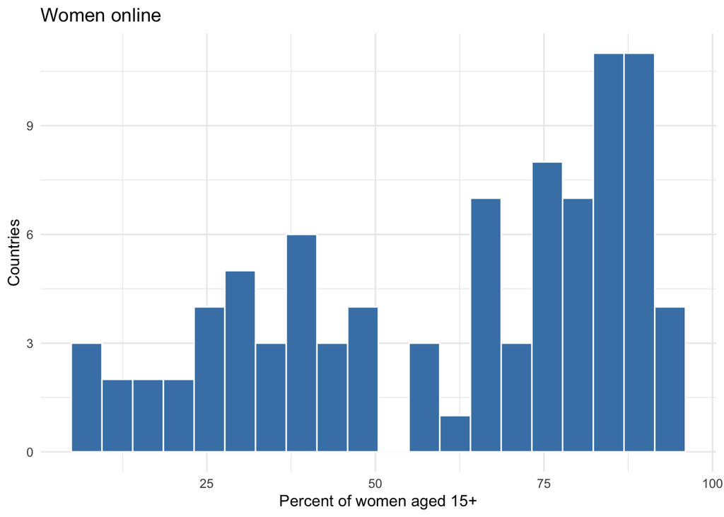

```r
ggplot(data, aes(x = internet_women)) +
  geom_histogram(bins = 20, fill = "steelblue", colour = "white") +
  labs(title = "Women online", x = "Percent of women aged 15+", y = "Countries") +
  theme_minimal()
```

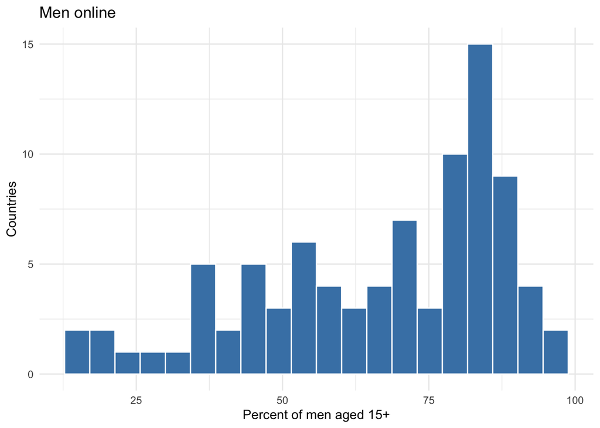

```r
ggplot(data, aes(x = internet_men)) +
  geom_histogram(bins = 20, fill = "steelblue", colour = "white") +
  labs(title = "Men online", x = "Percent of men aged 15+", y = "Countries") +
  theme_minimal()
```

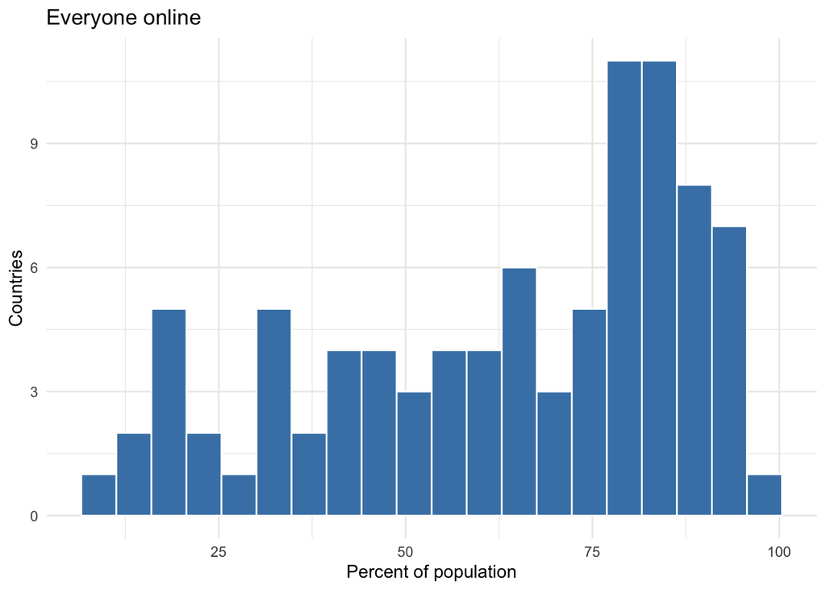

```r
ggplot(data, aes(x = internet_total)) +
  geom_histogram(bins = 20, fill = "steelblue", colour = "white") +
  labs(title = "Everyone online", x = "Percent of population", y = "Countries") +
  theme_minimal()
```

All three lean the same way: a tail stretching to the left, with more countries bunched at the high end. That makes sense, internet use has a ceiling at 100 percent, and a lot of countries are near it.

### The second gap measure

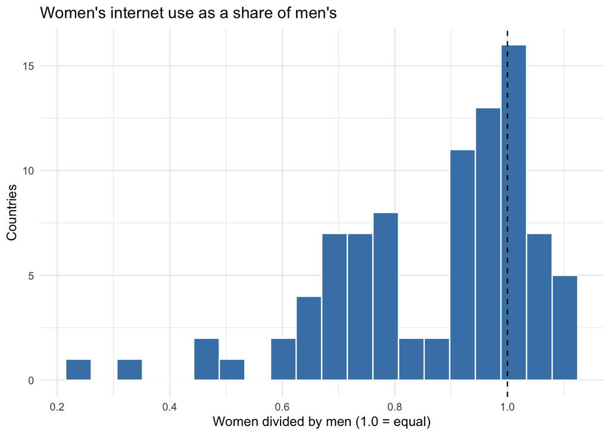

```r
ggplot(data, aes(x = gap_ratio)) +
  geom_histogram(bins = 20, fill = "steelblue", colour = "white") +
  geom_vline(xintercept = 1, linetype = "dashed") +
  labs(title = "Women's internet use as a share of men's",
       x = "Women divided by men (1.0 = equal)", y = "Countries") +
  theme_minimal()
```

### The three outcomes

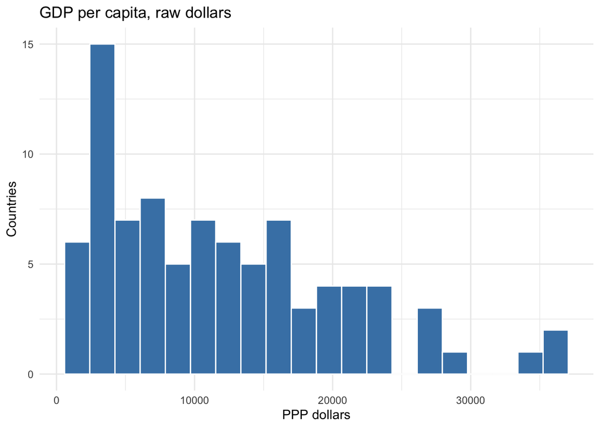

```r
ggplot(data, aes(x = gdp_pc_ppp)) +
  geom_histogram(bins = 20, fill = "steelblue", colour = "white") +
  labs(title = "GDP per capita, raw dollars",
       x = "PPP dollars", y = "Countries") +
  theme_minimal()
```

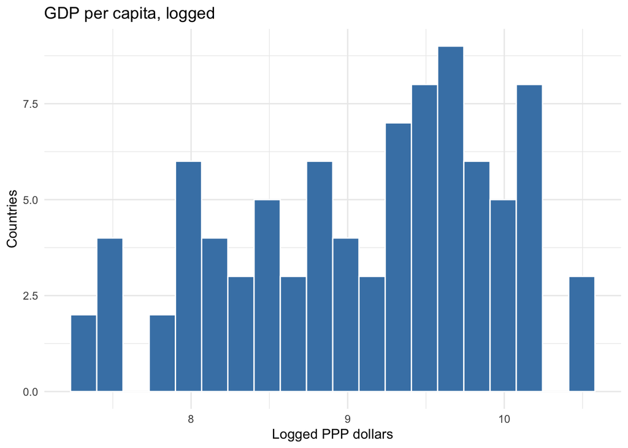

```r
ggplot(data, aes(x = log_gdp)) +
  geom_histogram(bins = 20, fill = "steelblue", colour = "white") +
  labs(title = "GDP per capita, logged",
       x = "Logged PPP dollars", y = "Countries") +
  theme_minimal()
```

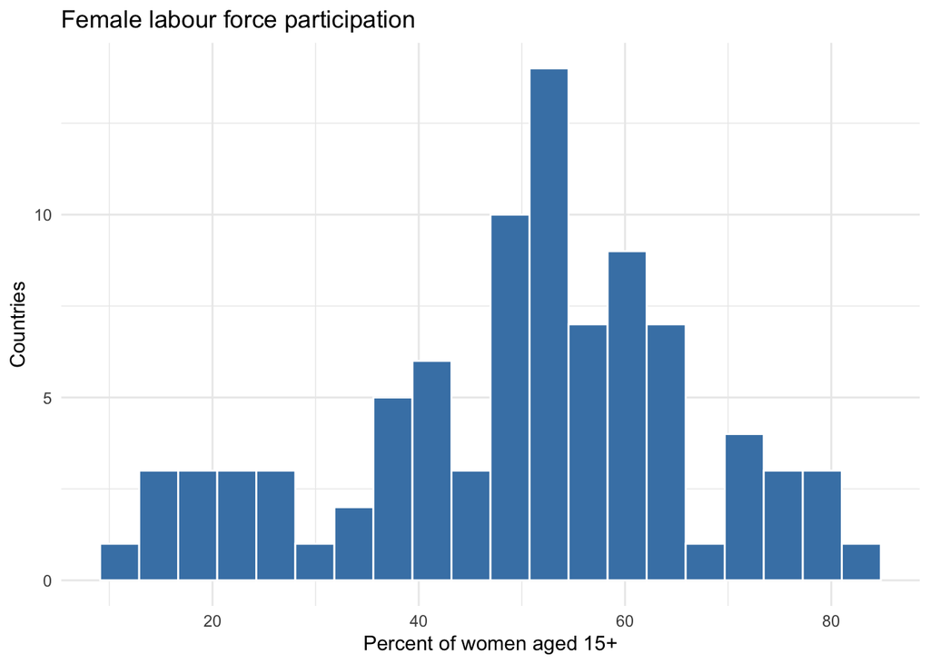

```r
ggplot(data, aes(x = flfp)) +
  geom_histogram(bins = 20, fill = "steelblue", colour = "white") +
  labs(title = "Female labour force participation",
       x = "Percent of women aged 15+", y = "Countries") +
  theme_minimal()
```

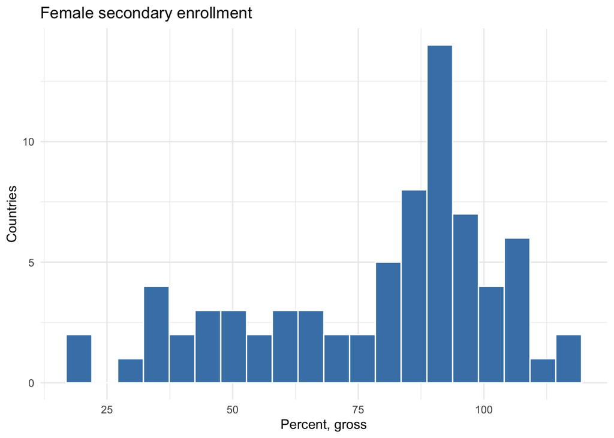

```r
ggplot(data, aes(x = sec_enroll_fem_gross)) +
  geom_histogram(bins = 20, fill = "steelblue", colour = "white") +
  labs(title = "Female secondary enrollment",
       x = "Percent, gross", y = "Countries") +
  theme_minimal()
```

The first two plots are the same variable before and after logging, and they show why I logged it. In raw dollars the countries pile up on the left with a long tail of richer ones stretching right. Logged, they spread out roughly evenly. That is the transformation doing its job.

### The two controls

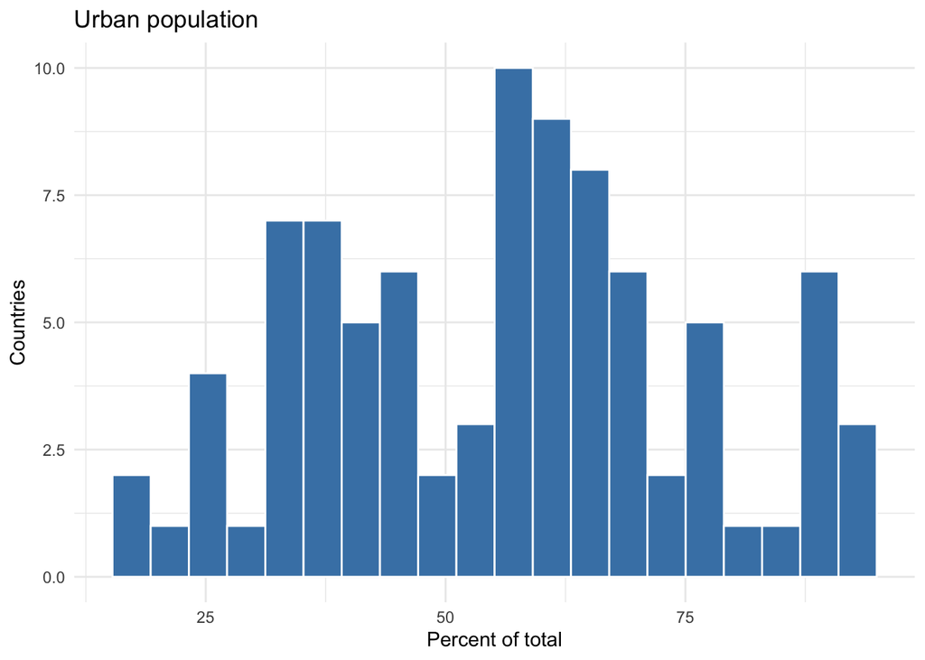

```r
ggplot(data, aes(x = urban_pct)) +
  geom_histogram(bins = 20, fill = "steelblue", colour = "white") +
  labs(title = "Urban population", x = "Percent of total", y = "Countries") +
  theme_minimal()
```

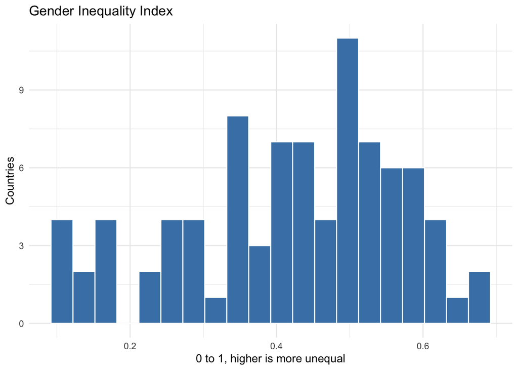

```r
ggplot(data, aes(x = gender_inequality_index)) +
  geom_histogram(bins = 20, fill = "steelblue", colour = "white") +
  labs(title = "Gender Inequality Index",
       x = "0 to 1, higher is more unequal", y = "Countries") +
  theme_minimal()
```

### Prediction:

The thing I am predicting is the outcome. That goes on the left of the ~ in R, and on the vertical axis in a plot. I have three of them: logged GDP per capita, female labour force participation, and female secondary enrollment.

The thing I am predicting with is the internet gender gap. That goes on the right of the ~, and on the horizontal axis.

```r
lm(flfp ~ gap_diff, data = data)
```

```
##
## Call:
## lm(formula = flfp ~ gap_diff, data = data)
##
## Coefficients:
## (Intercept)     gap_diff
##    50.39079     -0.09357
```

*Fitting the models, One predictor at a time*

**Logged GDP per capita**

```r
model_gdp <- lm(log_gdp ~ gap_diff, data = data)
summary(model_gdp)
```

```
##
## Call:
## lm(formula = log_gdp ~ gap_diff, data = data)
##
## Residuals:
##     Min      1Q  Median      3Q     Max
## -1.7115 -0.5318  0.1794  0.6015  1.4660
##
## Coefficients:
##              Estimate Std. Error t value Pr(>|t|)
## (Intercept)  9.331112   0.102729  90.832  < 2e-16 ***
## gap_diff    -0.039264   0.009813  -4.001 0.000133 ***
## ---
## Signif. codes:  0 '***' 0.001 '**' 0.01 '*' 0.05 '.' 0.1 ' ' 1
##
## Residual standard error: 0.7829 on 86 degrees of freedom
##   (1 observation deleted due to missingness)
## Multiple R-squared:  0.1569, Adjusted R-squared:  0.1471
## F-statistic: 16.01 on 1 and 86 DF,  p-value: 0.0001331
```

```r
confint(model_gdp)
```

```
##                   2.5 %      97.5 %
## (Intercept)  9.12689278  9.53533163
## gap_diff    -0.05877141 -0.01975603
```

The slope is −0.039, p = 0.0001, interval from −0.059 to −0.020. The interval does not contain zero.

Because the outcome is logged, that slope means about 4 percent lower GDP per capita for each extra percentage point of gap.

**Female labour force participation**

```r
model_flfp <- lm(flfp ~ gap_diff, data = data)
summary(model_flfp)
```

```
##
## Call:
## lm(formula = flfp ~ gap_diff, data = data)
##
## Residuals:
##     Min      1Q  Median      3Q     Max
## -37.451 -10.605   1.245  10.226  33.216
##
## Coefficients:
##             Estimate Std. Error t value Pr(>|t|)
## (Intercept) 50.39079    2.20710  22.831   <2e-16 ***
## gap_diff    -0.09357    0.21195  -0.441     0.66
## ---
## Signif. codes:  0 '***' 0.001 '**' 0.01 '*' 0.05 '.' 0.1 ' ' 1
##
## Residual standard error: 16.93 on 87 degrees of freedom
## Multiple R-squared:  0.002235,   Adjusted R-squared:  -0.009234
## F-statistic: 0.1949 on 1 and 87 DF,  p-value: 0.66
```

```r
confint(model_flfp)
```

```
##                  2.5 %     97.5 %
## (Intercept) 46.0039515 54.7776349
## gap_diff    -0.5148445  0.3277124
```

The slope is −0.094, p = 0.66, interval from −0.51 to 0.32. That interval contains zero comfortably, so I cannot distinguish this slope from nothing at all.

```r
model_enroll <- lm(sec_enroll_fem_gross ~ gap_diff, data = data)
summary(model_enroll)
```

```
##
## Call:
## lm(formula = sec_enroll_fem_gross ~ gap_diff, data = data)
##
## Residuals:
##     Min      1Q  Median      3Q     Max
## -61.320 -13.113   6.878  15.655  41.037
##
## Coefficients:
##             Estimate Std. Error t value Pr(>|t|)
## (Intercept)   85.107      3.094   27.51  < 2e-16 ***
## gap_diff      -1.207      0.301   -4.01 0.000147 ***
## ---
## Signif. codes:  0 '***' 0.001 '**' 0.01 '*' 0.05 '.' 0.1 ' ' 1
##
## Residual standard error: 22.28 on 72 degrees of freedom
##   (15 observations deleted due to missingness)
## Multiple R-squared:  0.1826, Adjusted R-squared:  0.1712
## F-statistic: 16.08 on 1 and 72 DF,  p-value: 0.0001465
```

```r
confint(model_enroll)
```

```
##                 2.5 %     97.5 %
## (Intercept) 78.938803 91.2748856
## gap_diff    -1.807279 -0.6070889
```

The slope is −1.21, p = 0.0001, interval from −1.81 to −0.61. A one point wider gap goes with about 1.2 percentage points lower enrollment.

This model uses 74 countries, not 89, because of the missing enrollment figures.

```r
model_gdp2 <- lm(log_gdp ~ gap_diff + internet_total + urban_pct, data = data)
summary(model_gdp2)
```

```
##
## Call:
## lm(formula = log_gdp ~ gap_diff + internet_total + urban_pct,
##     data = data)
##
## Residuals:
##      Min       1Q   Median       3Q      Max
## -1.48467 -0.24822  0.09277  0.24995  0.85640
##
## Coefficients:
##                Estimate Std. Error t value Pr(>|t|)
## (Intercept)    7.050511   0.181909  38.758   <2e-16 ***
## gap_diff       0.005498   0.006077   0.905    0.368
## internet_total 0.029999   0.002517  11.918   <2e-16 ***
## urban_pct      0.001971   0.003074   0.641    0.523
## ---
## Signif. codes:  0 '***' 0.001 '**' 0.01 '*' 0.05 '.' 0.1 ' ' 1
##
## Residual standard error: 0.4165 on 84 degrees of freedom
##   (1 observation deleted due to missingness)
## Multiple R-squared:  0.7669, Adjusted R-squared:  0.7586
## F-statistic: 92.13 on 3 and 84 DF,  p-value: < 2.2e-16
```

The gap’s slope goes to 0.005, p = 0.37. Indistinguishable from zero. Overall internet use absorbed the whole relationship, so that result was about development, not gender.